# NOAA Storm Database

Andrew Domenico

**Reproducible Research - Peer Graded Assignment 2**

## Synopsys

The basic goal of this assignment is to explore the NOAA Storm Database and answer some basic questions about severe weather events.

## Data Processing

Begin by setting options and importing libraries

```r
library(tidyverse)
library(ggplot2)
library(readr)
library(lubridate)
```

This project involves exploring the U.S. National Oceanic and Atmospheric Administration’s (NOAA) storm database. This database tracks characteristics of major storms and weather events in the United States, including when and where they occur, as well as estimates of any fatalities, injuries, and property damage.

The data is available from a public S3 bucket on AWS. We will create a data directory within the project and store the data there for further use.

```r
if(!dir.exists("./data")) {
  dir.create("./data")
} else {
  print("Data directory already exists")
}
```

```
[1] "Data directory already exists"
```

```r
#download the data, make note of the URL and time downloaded
fileUrl <- "https://d396qusza40orc.cloudfront.net/repdata%2Fdata%2FStormData.csv.bz2"
dest <- "./data/StormData.csv.bz2"
download.file(fileUrl, dest)
print(paste0('Data retrieved from ', fileUrl, ' at ', Sys.time()))
```

```
[1] "Data retrieved from https://d396qusza40orc.cloudfront.net/repdata%2Fdata%2FStormData.csv.bz2 at 2022-05-03 20:44:46"
```

The data from the .csv file can now be read into a data frame. This is raw data and will be explored. We expect to transform the data throughout the analysis.

```r
#unzip the file and read to a dataframe
raw_df <- read.csv(dest)
```

Conduct initial, exploratory analysis of the Storm Data

```r
summary(raw_df)
```

```
    STATE__       BGN_DATE           BGN_TIME          TIME_ZONE
 Min.   : 1.0   Length:902297      Length:902297      Length:902297
 1st Qu.:19.0   Class :character   Class :character   Class :character
 Median :30.0   Mode  :character   Mode  :character   Mode  :character
 Mean   :31.2
 3rd Qu.:45.0
 Max.   :95.0

     COUNTY       COUNTYNAME           STATE              EVTYPE
 Min.   :  0.0   Length:902297      Length:902297      Length:902297
 1st Qu.: 31.0   Class :character   Class :character   Class :character
 Median : 75.0   Mode  :character   Mode  :character   Mode  :character
 Mean   :100.6
 3rd Qu.:131.0
 Max.   :873.0

   BGN_RANGE          BGN_AZI           BGN_LOCATI          END_DATE
 Min.   :   0.000   Length:902297      Length:902297      Length:902297
 1st Qu.:   0.000   Class :character   Class :character   Class :character
 Median :   0.000   Mode  :character   Mode  :character   Mode  :character
 Mean   :   1.484
 3rd Qu.:   1.000
 Max.   :3749.000

   END_TIME           COUNTY_END COUNTYENDN       END_RANGE
 Length:902297      Min.   :0    Mode:logical   Min.   :  0.0000
 Class :character   1st Qu.:0    NA's:902297    1st Qu.:  0.0000
 Mode  :character   Median :0                   Median :  0.0000
                    Mean   :0                   Mean   :  0.9862
                    3rd Qu.:0                   3rd Qu.:  0.0000
                    Max.   :0                   Max.   :925.0000

   END_AZI           END_LOCATI            LENGTH              WIDTH
 Length:902297      Length:902297      Min.   :   0.0000   Min.   :   0.000
 Class :character   Class :character   1st Qu.:   0.0000   1st Qu.:   0.000
 Mode  :character   Mode  :character   Median :   0.0000   Median :   0.000
                                       Mean   :   0.2301   Mean   :   7.503
                                       3rd Qu.:   0.0000   3rd Qu.:   0.000
                                       Max.   :2315.0000   Max.   :4400.000

```

[output cut: 24 more lines]

```
   LONGITUDE        LATITUDE_E     LONGITUDE_       REMARKS
 Min.   :-14451   Min.   :   0   Min.   :-14455   Length:902297
 1st Qu.:  7247   1st Qu.:   0   1st Qu.:     0   Class :character
 Median :  8707   Median :   0   Median :     0   Mode  :character
 Mean   :  6940   Mean   :1452   Mean   :  3509
 3rd Qu.:  9605   3rd Qu.:3549   3rd Qu.:  8735
 Max.   : 17124   Max.   :9706   Max.   :106220
                  NA's   :40
     REFNUM
 Min.   :     1
 1st Qu.:225575
 Median :451149
 Mean   :451149
 3rd Qu.:676723
 Max.   :902297
```

```r
colnames(raw_df)
```

```
 [1] "STATE__"    "BGN_DATE"   "BGN_TIME"   "TIME_ZONE"  "COUNTY"
 [6] "COUNTYNAME" "STATE"      "EVTYPE"     "BGN_RANGE"  "BGN_AZI"
[11] "BGN_LOCATI" "END_DATE"   "END_TIME"   "COUNTY_END" "COUNTYENDN"
[16] "END_RANGE"  "END_AZI"    "END_LOCATI" "LENGTH"     "WIDTH"
[21] "F"          "MAG"        "FATALITIES" "INJURIES"   "PROPDMG"
[26] "PROPDMGEXP" "CROPDMG"    "CROPDMGEXP" "WFO"        "STATEOFFIC"
[31] "ZONENAMES"  "LATITUDE"   "LONGITUDE"  "LATITUDE_E" "LONGITUDE_"
[36] "REMARKS"    "REFNUM"
```

Convert the Begin and End dates from character to date format, and create a year column

```r
raw_df$BGN_DATE <- lubridate::mdy_hms(raw_df$BGN_DATE)
raw_df$END_DATE <- lubridate::mdy_hms(raw_df$END_DATE)
raw_df$year <- format(raw_df$BGN_DATE, format="%Y")
```

## Results

This analysis will address the following questions:

## Question 1

Across the United States, which types of events (as indicated in the EVTYPE variable) are most harmful with respect to population health?

Population health is measured in the columns ‘FATALITIES’ and ‘INJURIES’. We will need to group the event types together

```r
health_df <- raw_df %>%
  mutate(raw_df, event_type =
          case_when(grepl("FLOOD", EVTYPE) ~ "FLOOD",
                    grepl("HURRICANE", EVTYPE) ~ "HURRICANE",
                    grepl("WIND", EVTYPE) ~ "WIND",
                    grepl("ICE", EVTYPE) ~ "ICE",
                    grepl("THUNDERSTORM", EVTYPE) ~ "THUNDERSTORM",
                    grepl("FIRE", EVTYPE) ~ "FIRE",
                    grepl("TORNADO", EVTYPE) ~ "TORNADO",
                    TRUE ~ "OTHER")) %>%
  group_by(event_type, year) %>%
  summarize(total_fatalities = sum(FATALITIES), total_injuries=sum(INJURIES),
            total_impacted_ppl = total_fatalities+total_injuries) %>%
  filter(year >= 1992)
```

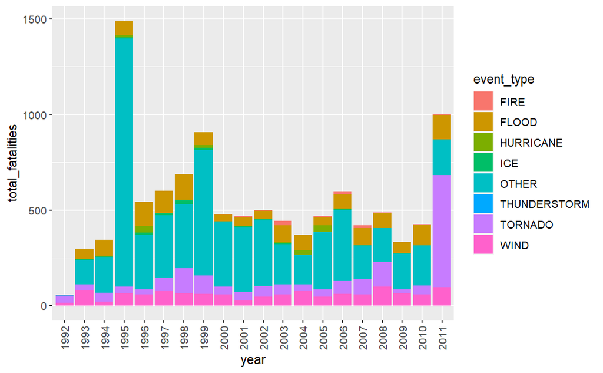

```r
ggplot(health_df, aes(x=year, y=total_fatalities, fill=event_type)) +
  geom_bar(position="stack", stat="identity") +
  theme(axis.text.x = element_text(angle = 90, hjust = 1, vjust = 0.5))
```

## Question 2

Across the United States, which types of events have the greatest economic consequences? Let’s examine the types of events by the amount of property and crop damage caused.

We want to convert the damage estimates from decimals to dollars. First, examine the possible values for the field PROPDMGEXP, which is used to multiply the values in PROPDMG and CROPDMG.

```r
unique(raw_df$PROPDMGEXP)
```

```
 [1] "K" "M" ""  "B" "m" "+" "0" "5" "6" "?" "4" "2" "3" "h" "7" "H" "-" "1" "8"
```

```r
unique(raw_df$CROPDMGEXP)
```

```
[1] ""  "M" "K" "m" "B" "?" "0" "k" "2"
```

```r
filtered_df <- raw_df %>%
  filter(PROPDMGEXP == "K" | PROPDMGEXP == "M" | PROPDMGEXP == "m" |
           PROPDMGEXP == "B" | PROPDMGEXP == "" | CROPDMGEXP == "K" |
           CROPDMGEXP == "M" | CROPDMGEXP == "m" | CROPDMGEXP == "B" |
           CROPDMGEXP == "k" | CROPDMGEXP == "")
```

Now, replace those letter values with the actual multiplier, and create a new column with the total property damage

```r
filtered_df <-
  mutate(filtered_df, multiplier = case_when(PROPDMGEXP == "K" ~ as.numeric(1000),
                                PROPDMGEXP == "M" ~ as.numeric(1000000),
                                PROPDMGEXP == "m" ~ as.numeric(1000000),
                                PROPDMGEXP == "B" ~ as.numeric(1000000000),
                                PROPDMGEXP == "" ~ as.numeric(1),
                                CROPDMGEXP == "K" ~ as.numeric(1000),
                                CROPDMGEXP == "M" ~ as.numeric(1000000),
                                CROPDMGEXP == "m" ~ as.numeric(1000000),
                                CROPDMGEXP == "B" ~ as.numeric(1000000000),
                                CROPDMGEXP == "k" ~ as.numeric(1000),
                                CROPDMGEXP == "" ~ as.numeric(1)
                                ))
```

Multiply the PROPDMG and the CROPDMG by the newly created multiplier and we have the numbers for both property & crop damages. Those damages summed equal total damage in dollar figures

```r
filtered_df <- filtered_df %>%
  mutate(property_damage = PROPDMG * multiplier) %>%
  mutate(crop_damage = CROPDMG * multiplier) %>%
  mutate(total_damages = property_damage + crop_damage)
```

For each year, we would like to know the total amounts of both property and crop damage caused. Since there are many variations on the event types, we can group some of them. For example, flash floods are types of floods, wildfires are types of fires, etc.

```r
economic_damage <- filtered_df %>%
  mutate(filtered_df, event_type =
          case_when(grepl("FLOOD", EVTYPE) ~ "FLOOD",
                    grepl("HURRICANE", EVTYPE) ~ "HURRICANE",
                    grepl("WIND", EVTYPE) ~ "WIND",
                    grepl("ICE", EVTYPE) ~ "ICE",
                    grepl("THUNDERSTORM", EVTYPE) ~ "THUNDERSTORM",
                    grepl("FIRE", EVTYPE) ~ "FIRE",
                    grepl("TORNADO", EVTYPE) ~ "TORNADO",
                    TRUE ~ "OTHER")) %>%
  group_by(year, event_type) %>%
  summarize(prop_dmg = sum(property_damage),
            crop_dmg = sum(crop_damage),
            total_dmg = sum(property_damage + crop_damage))
```

Now we can create some exploratory graphics which show the total damage by event type

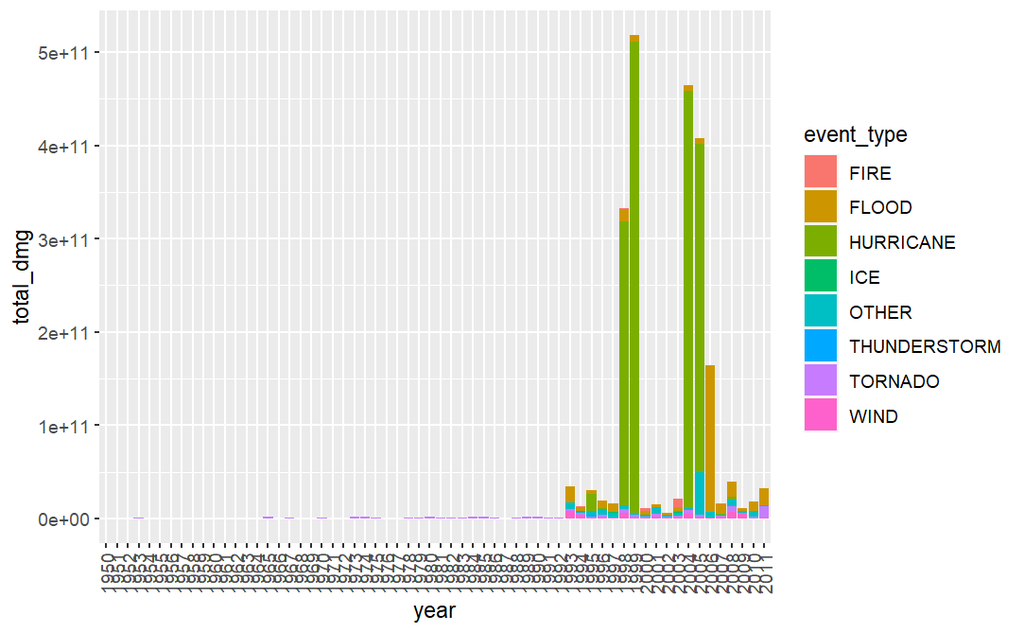

```r
ggplot(economic_damage, aes(x=year, y=total_dmg, fill=event_type)) +
  geom_bar(position="stack", stat="identity") +
  theme(axis.text.x = element_text(angle = 90, hjust = 1, vjust = 0.5))
```

```r
economic_damage <- economic_damage %>%
  filter(year >= 1992)
```

Additionally, the bar plot is a bit hard to read. A boxplot should be easier to compare values

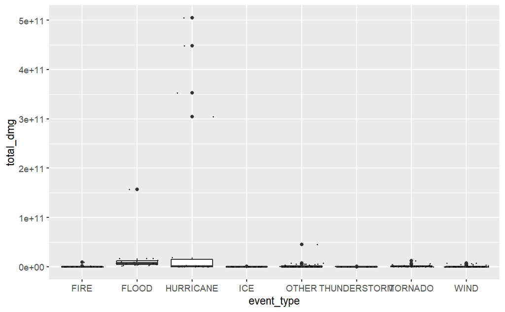

```r
ggplot(economic_damage, aes(x=event_type, y=total_dmg)) +
  geom_boxplot() +
  geom_jitter(color="black", size=0.4, alpha=0.9)
```

Clearly, Hurricanes are the most damaging severe weather event, even though there are few outlier events that dramatically push the total upwards. They are followed by floods which can be co-occuring with hurricanes.